# Final Paper

STOR 320.01 Group 2

November 28, 2021

# INTRODUCTION

When considering this data on some of the most popular songs on Spotify over the past year, two main questions stuck with our project team. The first of those was if musical components could predict song popularity. Second, we considered if the genre of songs was able to predict popularity. In theory, if we found strong statistical support for an answer to either question, we could use our analysis to help musicians create the most popular songs they could. Throughout this project our group learned about different musical components and what they mean. We attempted to build models and provide analysis that could be leveraged by musicians in order to create the most popular song possible. Further information about the dataset and our results will be provided throughout the rest of this paper.

# DATA

The dataset used in our project came from Sashank Pillai and identifies the top 200 chart of songs in 2020. This dataset includes all of the songs that have been on the Top 200 Weekly (Global) charts on Spotify in 2020 and 2021. There are many variables that make up the dataset that we found useful in order to answer our proposed questions. The variables we focused on were highest charting position, song name, streams, artist, genre, popularity, danceability, energy, and valence. A few of these variable names can explain themselves, such as highest charting position, number of streams, genre, popularity, artist, and song name, but a few that we looked at may need more explanation. Danceability describes how suitable a track is for dancing based on a combination of musical elements including tempo, rhythm stability, beat strength, and overall regularity. Danceability was measured from 0.0 to 1.0, with 0.0 being the least danceable and 1.0 is the most danceable. Energy represents a perceptual measure of intensity and activity from 0.0 to 1.0. Typically, energetic tracks feel fast, loud, and noisy and would measure closer to 1.0. Lastly, valence describes the musical positiveness conveyed by a track. Tracks with high valence sound more positive–songs that can be characterized as more happy, cheerful, or euphoric–while tracks with low valence sound more negative–songs that can be characterized as more sad, depressing, or angry. Valence is also measured on a 0.0 to 1.0 scale with negative songs measuring closer to 0.0 and positive songs measuring closer to 1.0. Below, is a small sample of our dataset including each song’s corresponding attributes:

```
##                           Song.Name Highest.Charting.Position    Streams
## 1                           Beggin'                         1 48,633,449
## 2         STAY (with Justin Bieber)                         2 47,248,719
## 3                          good 4 u                         1 40,162,559
## 4                        Bad Habits                         3 37,799,456
## 5 INDUSTRY BABY (feat. Jack Harlow)                         5 33,948,454
##           Artist                                  Genre Popularity Danceability
## 1       Måneskin ['indie rock italiano', 'italian pop']        100        0.714
## 2  The Kid LAROI                 ['australian hip hop']         99        0.591
## 3 Olivia Rodrigo                                ['pop']         99        0.563
## 4     Ed Sheeran                      ['pop', 'uk pop']         98        0.808
## 5      Lil Nas X          ['lgbtq+ hip hop', 'pop rap']         96        0.736
##   Energy Valence
## 1  0.800   0.589
## 2  0.764   0.478
## 3  0.664   0.688
## 4  0.897   0.591
## 5  0.704   0.894
```

Because “popularity” was such a significant variable in our dataset, we wanted to demonstrate the relationship between popularity and other attributes of a song (energy, loudness, danceability, etc.).

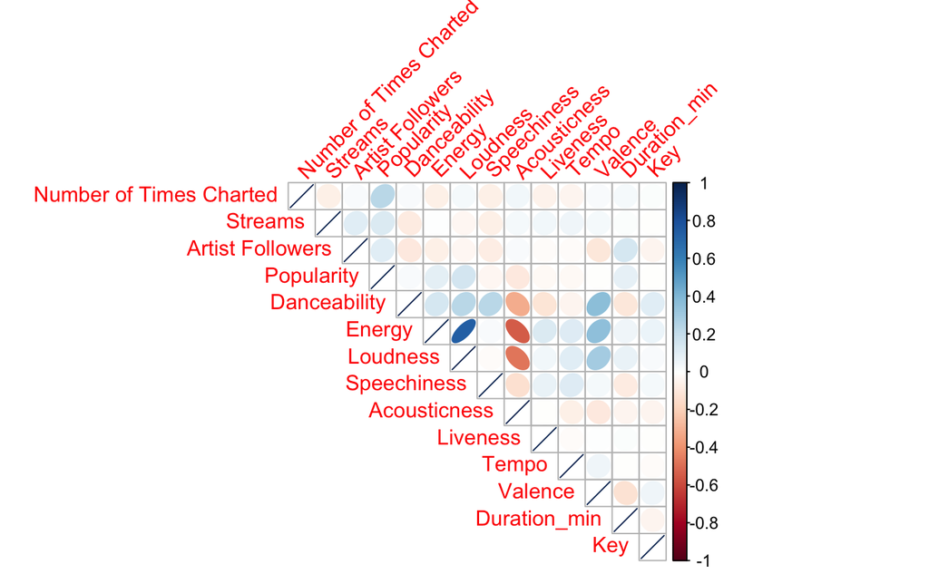

In the correlation plot above, the redder ellipses represent a negative correlation, whereas the blue ellipses represent a positive correlation. Looking at the popularity row, we can see that there is a positive correlation between popularity and loudness, popularity and energy, and popularity and duration. Thus, if we wanted to predict which songs are considered more popular, we might look to see which songs have a higher energy and loudness and a longer duration. If we look at the popularity column, we also observe that there is a positive correlation between popularity and number of times charted, streams, and artist followers; which we might expect without having previously looked at our data.

The variables used to answer the questions proposed help provide data to answer the questions regarding which musical components of songs on the Top 200 Spotify Charts in 2020 and 2021 lead to their popularity and if certain components predict the popularity of songs. The popularity, genre, and song name variables were used along with the different musical component variables to measure how they each related to the popularity of certain genres or songs in the Top 200 chart. The musical components of energy, valence, and danceability were chosen as our components of interest regarding songs in the Top 200 chart because they could be easily noticed by listeners, thus influencing the popularity of a song after the first listen. These musical components also inspired the follow up question regarding the continuous variable in the dataset that had the strongest association with popularity.

# RESULTS

### Q1: Could musical components predict song popularity on Spotify?

To answer our first question and attempt to predict s song’s popularity based on its musical characteristics, we first built a multiple regression model. Before fitting the model, we standardized all of the numerical variables to prevent variables that are measured at different scales contributing unequally to the analysis and creating biases. Then, we used all of the musical components, including nine numerical variables and one categorical variable, to predict song popularity. We found that the R-squared is 0.04494 with only three variables being significant in the model, including Loudness, Duration, and Key3, which is Chord D Sharp 7 in the song’s instrumental version. The result shows that our model can only explain about four percent of the variability of the Popularity, indicating that our model has little or no predictive power in estimating the popularity of songs. To get rid of variables that are not significant in the regression model and to improve the accuracy of prediction, we then conducted variable selection based on the least MSE (Mean squared error). After selecting, Loudness, Liveness, Tempo, Valence, and Duration remained in the regression model with an R-squared of 0.03488. There was no surprise to see the decrease in R-squared since we removed fifteen variables from the original model. Even though those variables are not significant in reducing the MSE of our model, they still have little predictive ability.

So, what we should do when musical components could hardly predict song popularity. After several experiments by adding one more variable into our model each time, we found that Artist is the most important predictor in the regression. By adding Artist, a categorical variable, into the previous model which has the least MSE, the R-squared improved from 0.03488 to 0.6426. However, this big jump is suspicious. Artist has 716 unique categories, whereas the whole dataset only has 1556 observations. Although there is no one-to-one correspondence between Artist and Popularity, when the number of the predictors is the half time of all observations, the regression is somewhat meaningless as the coefficient for each artist can adjust the predicted popularity to a large extent, leaving other predictors not that significant. So, we needed to select some categories from Artist to represent the Artist predictor.

Given the circumstances, we applied the Shrinkage Method to shrink unimportant coefficients toward zero and thus to reduce the number of estimators. We first built two models, one with all of the musical components, Artist, and interactions between them, giving us 14834 parameters. The other one is the same but without interaction terms, giving us 719 parameters. We then applied the shrinkage method on the two models by looping over each vector of alpha and finding the best lambda for each alpha considered. The table below is our output after shrinkage:

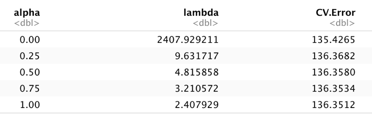

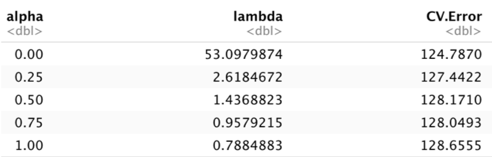

The table on the left is the output of the model with interaction terms. The result shows that alpha = 0 and lambda = 2407.93 is the best combination which leads to the least cross-validation error of 135.42. The big lambda suggests that many coefficients of the parameters were shrunk to 0. We could also learn this from the fact that the number of parameters reduced from 14834 to 8199, revealing that many variables could not help the model to predict Popularity. The table on the right is the output of the model without interaction terms. The best combination is alpha = 0 and lambda = 53.10, leading to the least cross-validation error of 124.79. The comparatively small lambda shows that many of the coefficients were not close to 0. And, surprisingly, the number of parameters before and after the shrinkage did not change, which is still 719, meaning none of the coefficients should be omitted. After knowing the two best models, we checked the prediction accuracy by plotting the prediction and actual Popularity on the same plot.

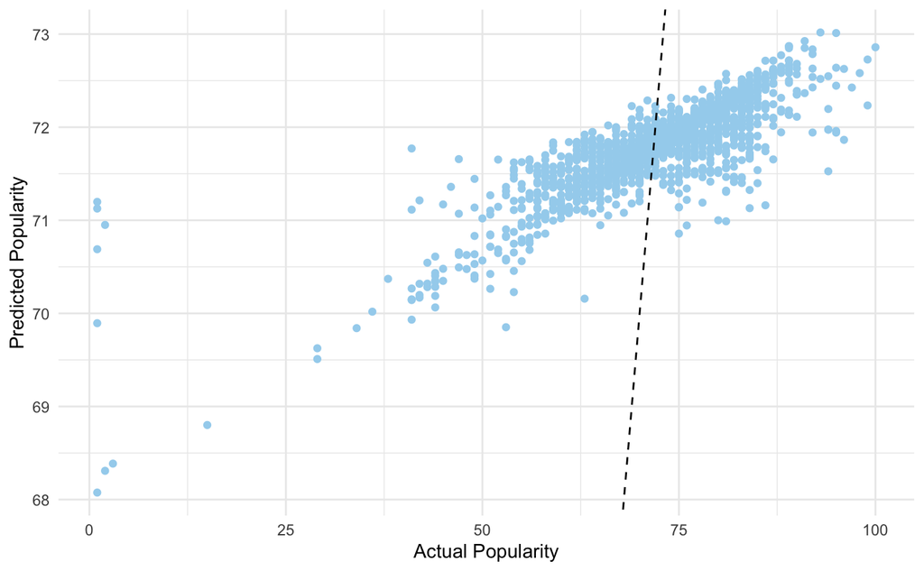

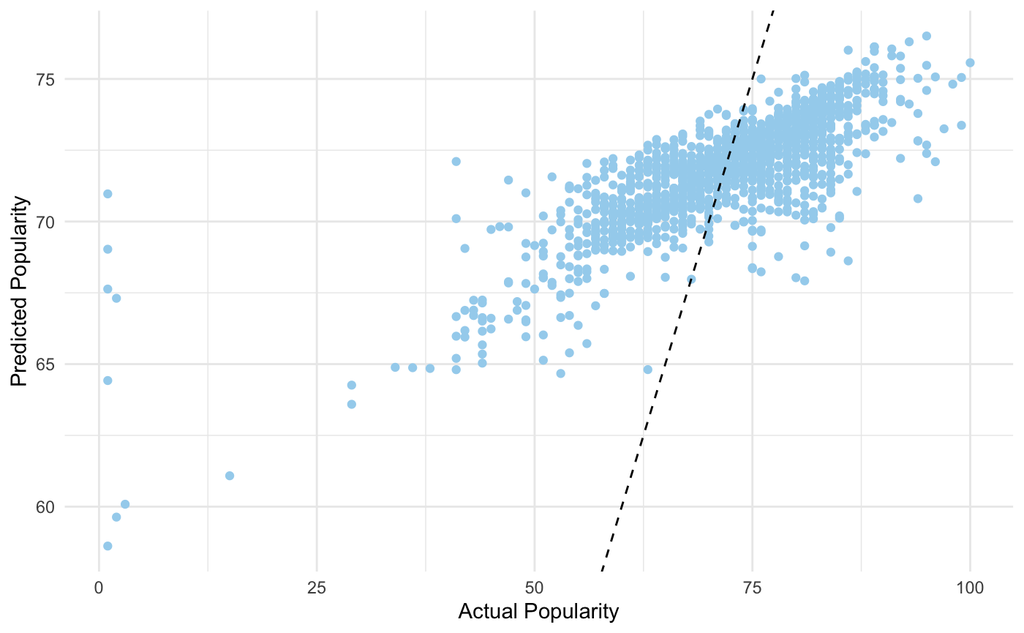

In conclusion, even if we added the most important variable, Artist, to the regression and utilized the Shrinkage method, we still could not accurately predict song popularity. It means that there is no way to predict popularity by merely relying on the intrinsic components of the song. External factors can exert heavy influences on song popularity, such as listener preferences, global music trends, marketing of each song, and current events of singers.

### Q2: Could musical genre predict song popularity on Spotify?

From the results of our exploratory data analysis, we found that the keyword “pop” appears the most frequent in the genre of songs from the Top 10 Artists, leading us to conclude that pop music is the most popular music genre among the top music artists in the dataset. This discovery made us wonder whether the music genre could have a predictive effect in estimating song popularity. Given the conclusion from Question 1 that there is no way to precisely predict song popularity, we stored Popularity into a binary response variable, Popularity=1 if Popularity is greater or equal to 75, and 0 otherwise. In that case, it allowed much easier predictions by only making classifications rather than estimating specific numbers. For the predictor variables, we utilized the same technique as treating the Popularity variable. For example, if a song involves K-pop in its list of genres, we will store 1 in the variable, K-pop, and 0 otherwise. The table below is the summary output of the predictor variable. Each number represents the total appearance of that music genre. We could find that pop and rap music rank the highest two.

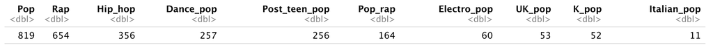

After managing our data, we first fitted all variables above in a logistic regression model to predict song popularity. From the summary output of the logistic model, variables, including pop, post-teen pop, rap, pop-rap, hip hop, and electro-pop, appeared to be significant. Then, we extracted those significant predictors, fitted another logistic regression model, and calculated the measure of accuracy by comparing it to the actual Popularity binary response variable. The accuracy turned out to be 0.5713368, which is not that bad, proving there is some relationship between musical genre and song popularity but not that strong.

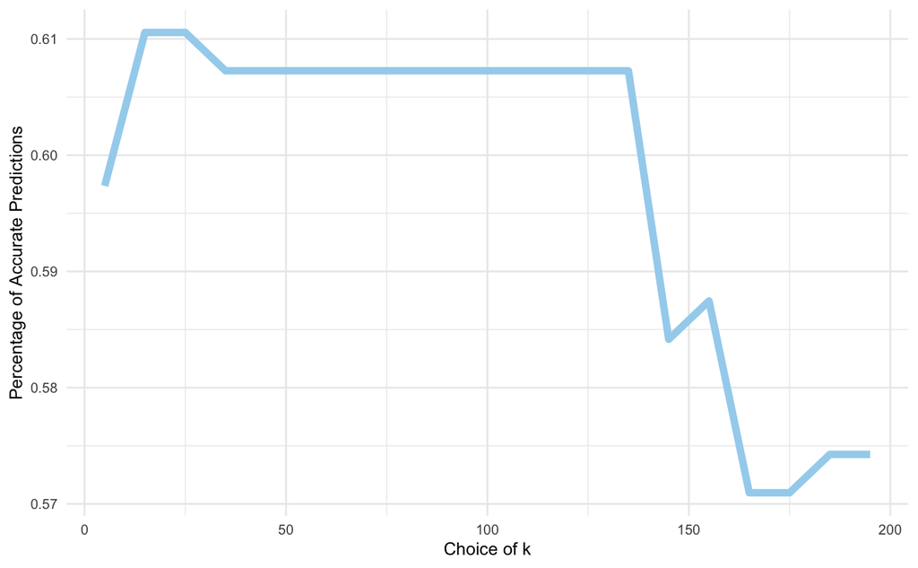

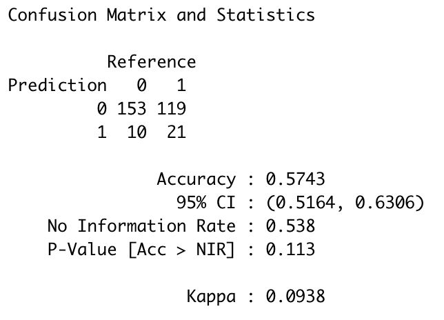

# CONCLUSION

In our investigation, we looked to analytically answer questions about what characteristics define popular music on music platforms like Spotify’s Top 200 Charts. We chose to do so because as avid music lovers, our group wanted to investigate and understand what factors (internal or external) really makes popular music. Our first question looked at the relationship between musical components and popularity of music, as we asked if musical components could predict song popularity on Spotify. After working through a multiple regression model, and then through variable selection by using least mean squared error as the criterion, we found that the variable artist was the biggest predictor of popularity. We created a shrinkage model and found that our model was unfortunately not able to tell us if internal factors/musical components could truly predict song popularity. Based on this, we concluded that song popularity is driven more by external factors such as listener preferences, global trends, song marketing, and current events surrounding singers. This is pertinent to the real world and heavily applicable to musical artists as our investigation tells us that the external factors that surround them and their lives have a greater influence than the technical aspects of music produced. It makes sense that artists that are advertised more and have more media coverage about them have more popular music, reiterating the importance of current events and marketing. One correlation that we found profoundly interesting between a musical component and song popularity was a weak positive correlation between duration and popularity. This was interesting as we’d expect song listeners in today’s world to dislike songs once they got “too long”, so this could possibly be a relationship to further investigate to better understand how human psychology could affect musical preferences.

Overall, this entire analytical project was a very interesting process for our group. We were able to learn a great amount about the technical aspects of music and some of the interesting relationships between those aspects and song popularity. If we were to lay out some suggestions to expand this analysis, we would first and foremost suggest expanding the number of years that the dataset covers. We were heavily restricted since our dataset only looked at Spotify’s Top 200 Charts in 2020 and 2021, giving us only 1556 observations. If someone were to study a wider period of time, they certainly would be able to better understand musical trends and also gain a better understanding of whether or not technical components really affect song popularity. The two questions we studied also potentially have connections to human psychology and decision making, which is another interesting avenue that could be taken to further expand this statistical research and analysis- by understanding the thought process behind decision making when listening to certain songs, we can expand the investigation past internal factors affecting song popularity. It’s a little difficult to turn external factors into variables or really things to study, so that is one roadblock that lies ahead if this research were to be expanded. Some more information that would be beneficial for analysis would include more identifying information about artists and production information of each of the songs. This would expand our ability to analyze how external factors contribute to song popularity, which would likely improve the accuracy of the shrinkage models that we created. Ultimately, we were able to come to some interesting statistical findings and create applicable models, but having some of the aforementioned information would have allowed us to expand our analysis to a further extent.